# paperball

Link to the main repo https://github.com/DanielWarshofsky/SillyBayesianStatistics.git

## Introduction

After two years of sitting at the middle desk on the east side of tate 201-07 my paper ball experiment has finally come to an end. Over these two years I have recorded every time I have attempted to throw a paper ball into the garbage can from sitting at my desk. Many people (Bonnabelle, Breandan, Ally, Chris and more) have witnessed my experiment take place. Now that it is over it is time to do a thorough analysis of the results.

## The Data

For self loathing reasons I thought the best way to collect the data was to record the number of failed attempts before I successfully landed a paper ball in the trash.

```python
import numpy as np
data=np.array([22,23,28,11,7,29,23,31,3,15,6,0,0,11,11])
#not included is the last 2 attempts
#for which I have not made a shot since
```

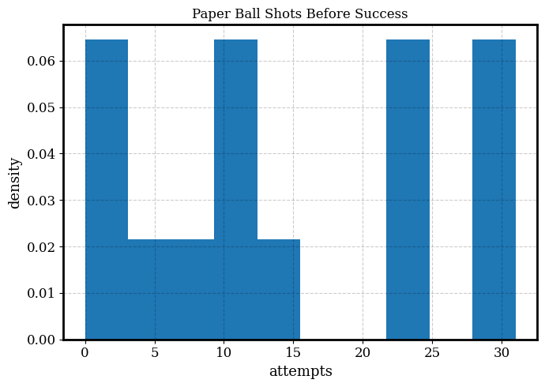

```python
import matplotlib.pyplot as plt
# Lets look at a histogram of the data
fig,ax=plt.subplots()
_=ax.hist(data,density=True)
ax.set_title('Paper Ball Shots Before Success')
ax.set_ylabel('density')
ax.set_xlabel('attempts')
plt.tight_layout()
```

```python
# now some basic summary statistics
total_success_rate=len(data)/(data.sum()+len(data))
mean_shots_missed=data.mean()
median_shots_missed=np.median(data)
std_shots_missed=data.std()
print(f'Total success rate: {total_success_rate:.3f}, '+
      f'Mean number of misses {mean_shots_missed:.3f}, '+
      f'Meadian number of misses {median_shots_missed:.3f}, '+
      f'Standard deviation of misses {std_shots_missed:.3f}')
```

```
Total success rate: 0.064, Mean number of misses 14.667, Meadian number of misses 11.000, Standard deviation of misses 10.274
```

It can be noted that I am quite bad at throwing paper balls in the trash. Don't worry I recycled every piece of paper thrown!

## Baysian Analysis

For some reason I feel obligated to put this here $$ P(\theta|x) \sim P(x|\theta)P(\theta) $$ moving on

There are a few questions that I want to answer with this analysis 1) What is the chance, per attempt , that I make the paper ball into the trash 2) Was there any significant improvement over time

To answer this question it is best to model the data with a geometric distribution $$ P(x|\theta)=\theta(1-\theta)^{x-1} $$ Where $\theta$ is the success rate of a single throw and $x$ is the number of attempts untill a success occurs. In this formalism $x$ is our data plus 1 to include the trail that succeeded.

Optimistically I throught that I would make about 1/4 of all shots so I'll pick a prior with a mean around .25 with low power at high values. I'll pick a Beta distribution with $\alpha=1.5$ and $\beta=5$ as defined by pymc

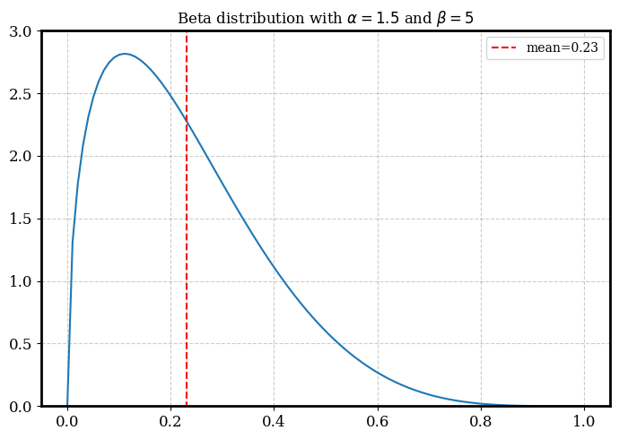

```python
from scipy.stats import beta
#Here is a plot of the prior so you dont think im that crazy
plot_prior=beta(a=1.5,b=5) # this is defined the same as pymc ... trust me
fig,ax=plt.subplots()
ax.plot(np.linspace(0,1,100),plot_prior.pdf(np.linspace(0,1,100)))
_=ax.set_title(r'Beta distribution with $\alpha=1.5$ and $\beta=5$')
ax.vlines(plot_prior.stats(moments='m'),-.1,3,label=f"mean={plot_prior.stats(moments='m'):.2f}",linestyles='--',color='r')
ax.set_ylim(0,3)
ax.legend()
plt.tight_layout()
```

Looks like a fair prior to me

Now we can answer the first question. What is the global value of $\theta$?

```python
import pymc as pm
from pymc import Geometric,Beta,Model

global_model=Model()

with global_model as model:
    #The input data, add 1 to include the success
    x=pm.MutableData(name='data',value=data+1)
    #prior on theta
    theta=Beta(name='theta',alpha=1.5,beta=5)
    # Likelyhood
    recorded_attempts=Geometric(name='NumberTrials',p=theta,observed=x)

    global_sample=pm.sample(10000)
```

```
Auto-assigning NUTS sampler...
Initializing NUTS using jitter+adapt_diag...
Multiprocess sampling (4 chains in 4 jobs)
NUTS: [theta]
```

100.00% [44000/44000 00:05<00:00 Sampling 4 chains, 0 divergences]

```
Sampling 4 chains for 1_000 tune and 10_000 draw iterations (4_000 + 40_000 draws total) took 18 seconds.
```

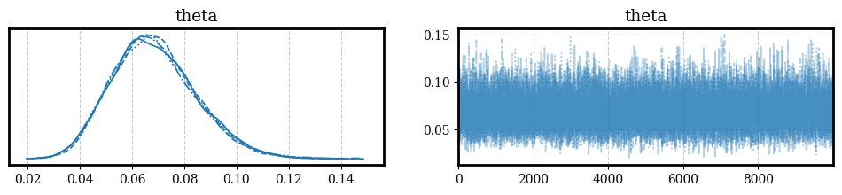

```python
import arviz as az
_=az.plot_trace(global_sample)
```

The sampler converged nicely

```python
global_summary=az.summary(global_sample)
print(f'The mean value for the global success rate is {global_summary["mean"].to_numpy()[0]}')
```

```
The mean value for the global succes rate is 0.069
```

As expected this is consistent with the naive estimate that was made by doing a simple ratio

Now let's see if I made any improvements! I'll do this by redoing the analysis but using different windows of the data. There are 15 samples so let's use a window of 5 data points at a time.

```python
models=[]
samples=[]

for i in range(0,10):
    subset_data=data[i:i+5] # get the sub window
    window_model=Model()
    with window_model as model:
        #The input data, add 1 to include the success
        x=pm.MutableData(name='data',value=subset_data+1)
        #prior on theta
        theta=Beta(name='theta',alpha=1.5,beta=5)
        # Likelyhood
        recorded_attempts=Geometric(name='NumberTrials',p=theta,observed=x)
        window_sample=pm.sample(10000,progressbar=False)
    samples.append(window_sample)
    models.append(window_model)
    del window_model
```

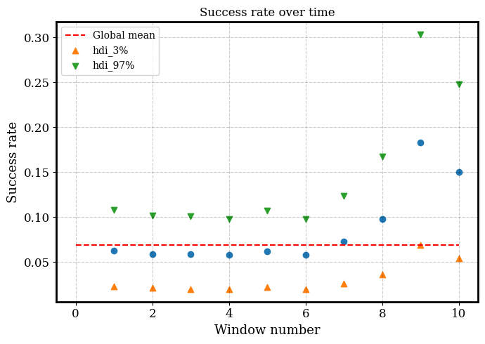

```python
improvement=np.array([[az.summary(x)['mean'].to_numpy()[0],az.summary(x)['hdi_3%'].to_numpy()[0],az.summary(x)['hdi_97%'].to_numpy()[0]] for x in samples])
fig,ax=plt.subplots()
ax.plot(np.linspace(0,10,100),global_summary["mean"].to_numpy()[0]*np.ones(100),linestyle='--',color='r',label='Global mean')
ax.scatter(np.arange(0,10)+1,improvement[:,0])
ax.scatter(np.arange(0,10)+1,improvement[:,1],label='hdi_3%',marker='^')
ax.scatter(np.arange(0,10)+1,improvement[:,2],label='hdi_97%',marker='v')
ax.set_title('Success rate over time')
ax.set_ylabel('Success rate')
ax.set_xlabel('Window number')
ax.legend()
plt.tight_layout()
```

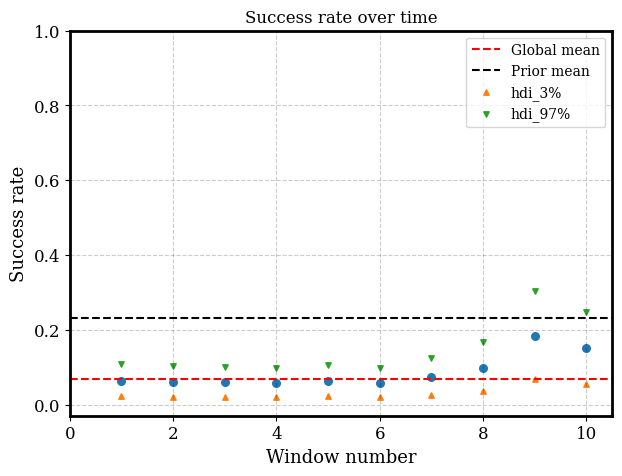

```python
improvement=np.array([[az.summary(x)['mean'].to_numpy()[0],az.summary(x)['hdi_3%'].to_numpy()[0],az.summary(x)['hdi_97%'].to_numpy()[0]] for x in samples])
fig,ax=plt.subplots()
ax.plot(np.linspace(0,11,100),global_summary["mean"].to_numpy()[0]*np.ones(100),linestyle='--',color='r',label='Global mean')
ax.plot(np.linspace(0,11,100),plot_prior.stats(moments='m')*np.ones(100),linestyle='--',color='k',label='Prior mean')
ax.scatter(np.arange(0,10)+1,improvement[:,0],s=30)
ax.scatter(np.arange(0,10)+1,improvement[:,1],label='hdi_3%',marker='^',s=15)
ax.scatter(np.arange(0,10)+1,improvement[:,2],label='hdi_97%',marker='v',s=15)
ax.set_title('Success rate over time')
ax.set_ylabel('Success rate')
ax.set_xlabel('Window number')
ax.set_ylim(-.03,1)
ax.set_xlim(0,10.5)
ax.legend()
```

### I clearly overestimated my paper ball throwing technique :(

I've also done more work than I needed to. The Beta distribution is the conjugate prior of the geometric distribution so we could have easily avoided all of this sampling nonsense and done the following.

```python
prior_alpha=1.5
prior_beta=5
means=[]
stds=[]
for i in range(0,10):
    subset_data=data[i:i+5]+1 # get the sub window and add 1
    #look at wikipedia here https://en.wikipedia.org/wiki/Conjugate_prior
    post_alpha=prior_alpha+5
    post_beta=prior_beta+subset_data.sum()
    means.append(post_alpha/(post_alpha+post_beta))
    stds.append(np.sqrt((post_alpha*post_beta)/((post_alpha+post_beta+1)*(post_beta+post_alpha)**2)))
```

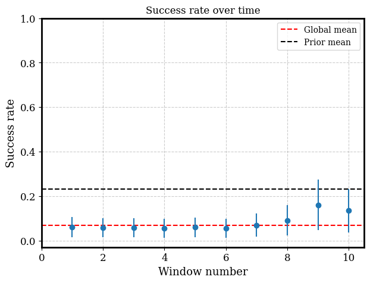

```python
fig,ax=plt.subplots()
ax.plot(np.linspace(0,11,100),global_summary["mean"].to_numpy()[0]*np.ones(100),linestyle='--',color='r',label='Global mean')
ax.plot(np.linspace(0,11,100),plot_prior.stats(moments='m')*np.ones(100),linestyle='--',color='k',label='Prior mean')
ax.errorbar(np.arange(0,10)+1,means,yerr=2*np.array(stds),fmt='o')
ax.set_title('Success rate over time')
ax.set_ylabel('Success rate')
ax.set_xlabel('Window number')
ax.set_ylim(-.03,1)
ax.set_xlim(0,10.5)
ax.legend()
```

These results with 2 sigma error bars are almost identical to the sampling approach

## Disscusion and Future Work

After much too in-depth analysis It pains me to report that my paper ball throwing prowess is not only worse than I had thought, I also made no significant improvement over 2 years. There are many ways to put my performance into perspective, by far the worst is the fact that over 2 years I only successfully threw 15 paper balls into the garbage. While this was a fun exercise the experimental design was too simple to yield any truly interesting results, there were just too few variables in play. Now that I have moved to tate 201-08 I propose a new experiment that everyone can participate in! I have scribed a target onto the glass window (its dry erase, don't worry) for the toy dart gun that came with the office. The experiment will consist of participants standing outside of the office, behind the sliding door and shooting one dart at the target and recording their score along with the time in date of the shot (https://docs.google.com/spreadsheets/d/1Sl-eV6wPPgz0wzxQ-nmaDdVh_KjiAMMZemnZl5Y80UM/edit?usp=sharing). At the end of the school year (or maybe semester) I will provide an update of this new experiment. I encourage everyone to participate!

```python
import pylab
global_params = {
    'text.usetex' : False,
    'font.family' : 'serif',
    'font.sans-serif' : ['Helvetica'],
    'ps.usedistiller' : 'xpdf',
    'ps.distiller.res' : 3000,
    'axes.labelsize' : 13,
          #'text.fontsize' : 16,
    'legend.fontsize' : 10,
    'xtick.labelsize' : 12,
    'ytick.labelsize' : 12,
    'axes.linewidth': 2.0,
    'axes.grid':True,
    'figure.figsize' : [7,5],
    'grid.linestyle':'--',
    'grid.color':'k',
    'grid.alpha':0.2}
pylab.rcParams.update(global_params)
```